# esm206_lab5

Alexandria Wilkins

10/29/2019

#### Lab 5 Objectives

- Learn to parse states with the ‘lubridate’ package
- Get counts of observations with count()
- Uncount() rows
- One and two-sample t-test
- Create a heatmap woth geom_tile()

Use tidyr::uncount() function to converts our lobster data from frequency format to case format, where every observation has its own cell.

```r
lobster_tidy <- lobster_abundance %>%
  tidyr::uncount(lobster_count)
```

We’re only going to consider ‘site’ as our something of interest

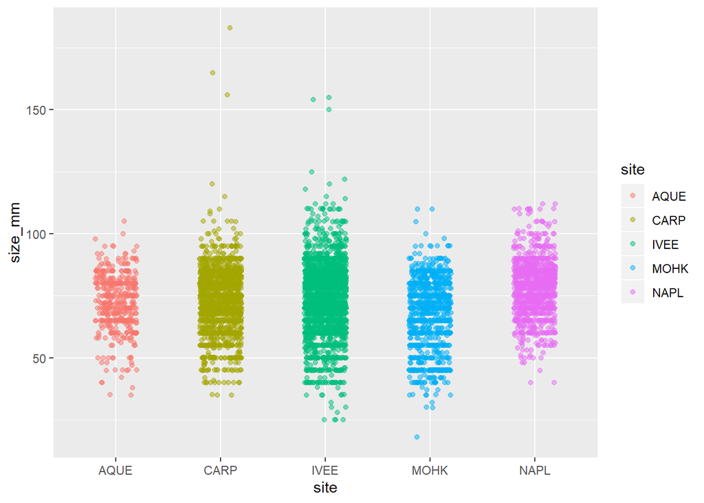

```r
ggplot(data = lobster_tidy, aes(x = site, y = size_mm)) +
  geom_jitter(aes(color = site),
              alpha = 0.5,
              width = 0.2)
```

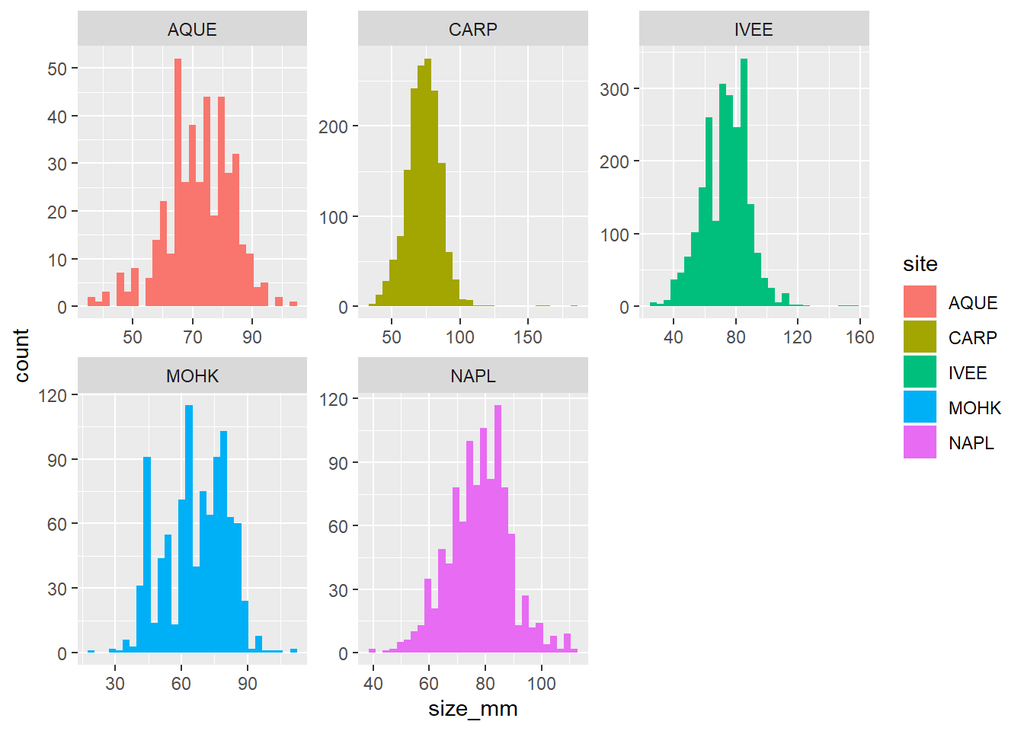

```r
# Histogram
ggplot(lobster_tidy, aes(x = size_mm)) +
  geom_histogram(aes(fill = site)) +
  facet_wrap(~site, scales = "free")
```

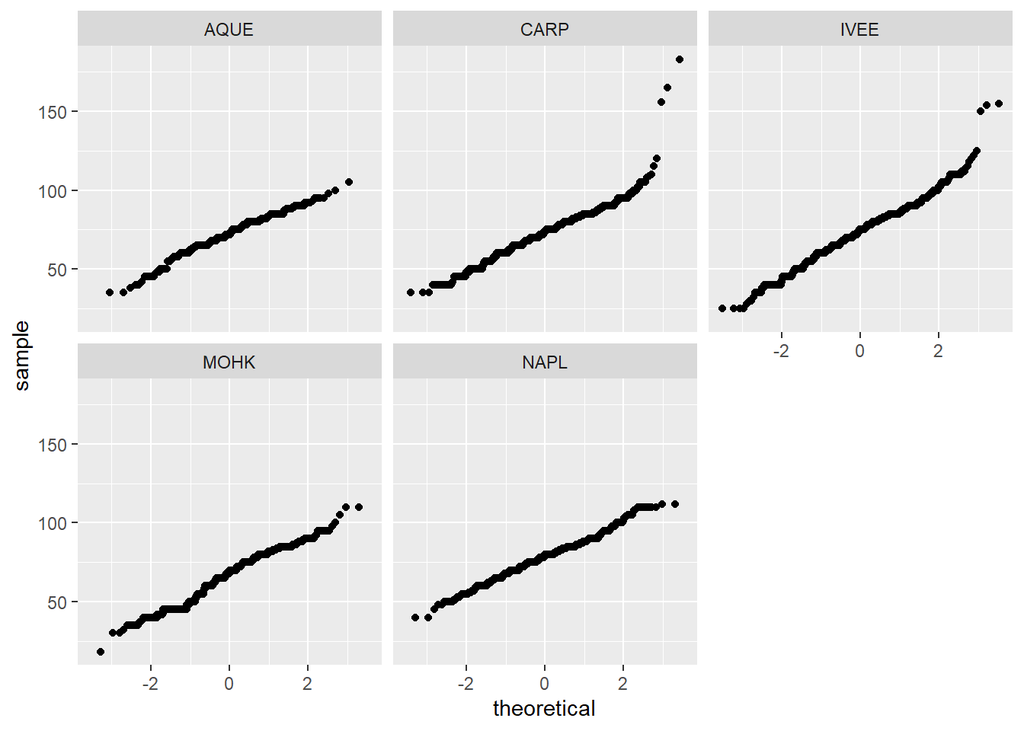

```r
#Quantile-quantile plot
ggplot(lobster_tidy, aes(sample = size_mm)) +
  geom_qq()+
  facet_wrap(~site)
```

#### Convert the ‘date’ column tp class ‘Date’

We’ll use the ‘lubridate’ package to convert to Date format, and then to help us easily parse month and year

```r
lobster_date <- lobster_tidy %>%
  mutate(date_new = lubridate::mdy(date))
```

Now, let’s parse year and month using lubridate::month() and lubridate::year()

```r
lobster_parse_date <- lobster_date %>%
  mutate(
    obs_month = lubridate::month(date_new, label = TRUE),
    obs_year = lubridate::year(date_new)
  )
```

Note: ‘label = TRUE’ in lubridate() gives month name abbreviation

Now, let’s find counts of observed lobsters based on different hierarchical groupings using the count() function.

First, let’s count lobsters by year and month, just year, and just site.

```r
lobster_ym <- lobster_parse_date %>%
  dplyr::count(obs_year, obs_month)

lobster_y <- lobster_parse_date %>%
  dplyr::count(obs_year)

lobster_site_count <- lobster_parse_date %>%
  dplyr::count(site)
```

If we want to create a summary table with statistics OTHER than counts by group, it’s easier to use group_by() + n().

```r
lobster_summary <- lobster_parse_date %>%
  group_by(site) %>%
  summarize(
    mean_size = mean(size_mm, na.rm = TRUE),
    sd_size = sd(size_mm, na.rm = TRUE),
    lobster_number = n())
```

#### Find Confidence Intervals

Use t.test() function to find convidence intervals(for one sample) and to compare means of two samples(…this will be covered conceptually in week 6)

```r
ivee_lobsters <- lobster_tidy %>%
  filter(site == "IVEE") %>%
  pull(size_mm)

t.test(ivee_lobsters)
```

```
##
##  One Sample t-test
##
## data:  ivee_lobsters
## t = 245.23, df = 2302, p-value < 2.2e-16
## alternative hypothesis: true mean is not equal to 0
## 95 percent confidence interval:
##  72.99130 74.16806
## sample estimates:
## mean of x
##  73.57968
```

#### Two-sample t-test to compare means

We want to ask: Is there a significant differenc in lobster lengths in Naples and Mohawk reefs?

We’ve done our necessary exploratory analyses to determine that a two-sample t-test for means comparison is appropriate.

```r
# 1st Method
napl_sample <- lobster_tidy %>%
  filter(site == "NAPL") %>%
  pull(size_mm)

mohk_sample <- lobster_tidy %>%
  filter(site == "MOHK") %>%
  pull(size_mm)

mn_ttest <- t.test(mohk_sample, napl_sample)

mn_ttest
```

```
##
##  Welch Two Sample t-test
##
## data:  mohk_sample and napl_sample
## t = -19.849, df = 1850.8, p-value < 2.2e-16
## alternative hypothesis: true difference in means is not equal to 0
## 95 percent confidence interval:
##  -12.43436 -10.19806
## sample estimates:
## mean of x mean of y
##  66.86833  78.18454
```

```r
lobster_mn <- lobster_tidy %>%
  filter(site %in% c("NAPL", "MOHK"))

mn_ttest2 <- t.test(size_mm ~ site, data = lobster_mn)

mn_ttest2
```

```
##
##  Welch Two Sample t-test
##
## data:  size_mm by site
## t = -19.849, df = 1850.8, p-value < 2.2e-16
## alternative hypothesis: true difference in means is not equal to 0
## 95 percent confidence interval:
##  -12.43436 -10.19806
## sample estimates:
## mean in group MOHK mean in group NAPL
##           66.86833           78.18454
```

```r
mn_ttest2$p.value
```

```
## [1] 1.215408e-79
```

```r
mn_ttest2$statistic
```

```
##         t
## -19.84873
```

summary statements should, of course, be developed for reproducibility!

#### Now a heatmap!

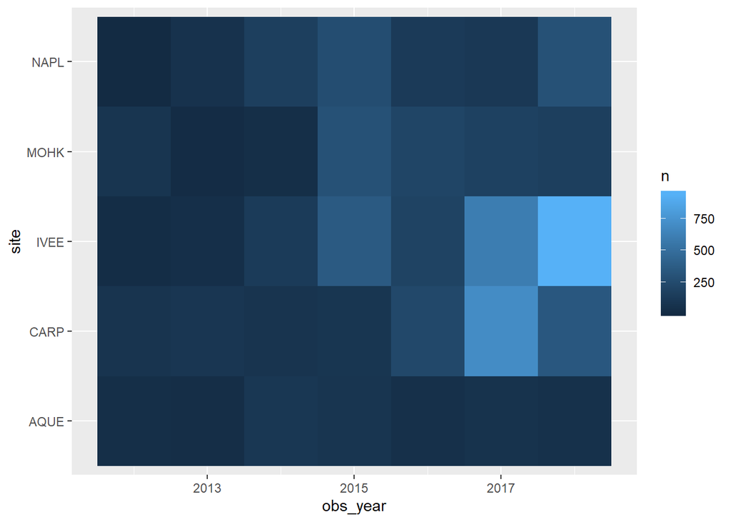

```r
lobster_ys <- lobster_parse_date %>%
  count(obs_year, site)

ggplot(data = lobster_ys, aes(x = obs_year, y = site))+
  geom_tile(aes(fill = n))
```